# Analysis

Stefano Coretta

2022-04-03

# 1 Tips

- Create one RStudio project per project, i.e. one folder per project.
- From Tools > Global options > General > Basic, untick “Restore .RData into workspace” and choose “Never” in “Save workspace to .Rdata”.
- Keep data and code separate.

# 2 Read data

```r
gestures <- read_csv("./02-import-viz/gestures.csv")
```

After reading data make sure you do data checks (such as checking that all the columns are there, that each column is of the right type, that there aren’t errors in the data, etc).

A quick look at the tibble.

```r
gestures
```

```
## # A tibble: 1,620 × 10
##    dyad  background months task  gesture count_raw count ct_raw    ct pro_rata
##    <chr> <chr>       <dbl> <chr> <chr>       <dbl> <dbl>  <dbl> <dbl> <chr>
##  1 b01   Bengali        10 five  reach           5     5      1     1 no
##  2 b01   Bengali        10 five  point           0     0      0     0 no
##  3 b01   Bengali        10 five  ho_gv           0     0      0     0 no
##  4 b01   Bengali        10 tp1   reach           0     0      0     0 no
##  5 b01   Bengali        10 tp1   point           0     0      0     0 no
##  6 b01   Bengali        10 tp1   ho_gv           0     0      0     0 no
##  7 b01   Bengali        10 tp2   reach           0     0      0     0 no
##  8 b01   Bengali        10 tp2   point           0     0      0     0 no
##  9 b01   Bengali        10 tp2   ho_gv           0     0      0     0 no
## 10 b01   Bengali        11 five  reach           7     8      3     3 yes
## # … with 1,610 more rows
```

Remeber: tidy data is data in which columns are variables and rows are observations.

Sometimes the same data can be thought of as an observation or as a variable. That depends on your analysis or which plot you want to make.

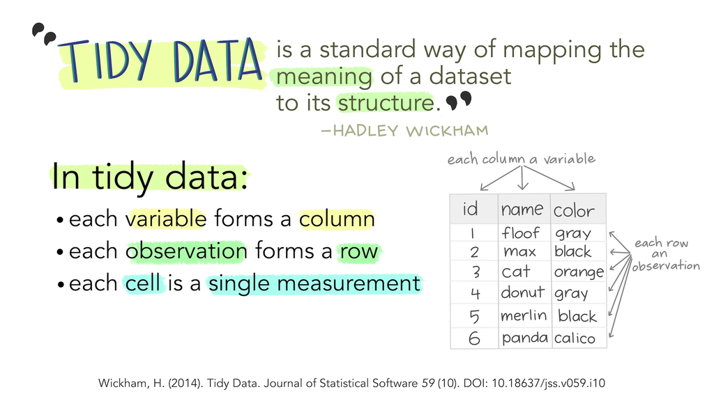

(Find more illustrations here: https://github.com/allisonhorst/stats-illustrations).

# 3 Summaries

Let’s just count the number of observations for each background.

```r
gestures %>%
  count(background)
```

```
## # A tibble: 3 × 2
##   background     n
##   <chr>      <int>
## 1 Bengali      540
## 2 Chinese      540
## 3 English      540
```

What if we want to know how many dyads there are per background?

```r
gestures %>%
  distinct(dyad, background) %>%
  count(background)
```

```
## # A tibble: 3 × 2
##   background     n
##   <chr>      <int>
## 1 Bengali       20
## 2 Chinese       20
## 3 English       20
```

Let’s get some summaries.

You can use a combination of `group_by()` and `summarise()`.

```r
gestures %>%
  group_by(background, gesture) %>%
  summarise(
    count_median = median(count, na.rm = TRUE),
    median_max = max(count, na.rm = TRUE)
  )
```

```
## # A tibble: 9 × 4
## # Groups:   background [3]
##   background gesture count_median median_max
##   <chr>      <chr>          <dbl>      <dbl>
## 1 Bengali    ho_gv              0         22
## 2 Bengali    point              0         19
## 3 Bengali    reach              0         16
## 4 Chinese    ho_gv              0         28
## 5 Chinese    point              0         19
## 6 Chinese    reach              0         10
## 7 English    ho_gv              0         12
## 8 English    point              0         42
## 9 English    reach              0         13
```

```r
gestures %>%
  group_by(background, gesture, months) %>%
  summarise(
    count_median = median(count, na.rm = TRUE),
    median_max = max(count, na.rm = TRUE)
  )
```

```
## # A tibble: 27 × 5
## # Groups:   background, gesture [9]
##    background gesture months count_median median_max
##    <chr>      <chr>    <dbl>        <dbl>      <dbl>
##  1 Bengali    ho_gv       10            0          8
##  2 Bengali    ho_gv       11            0         17
##  3 Bengali    ho_gv       12            1         22
##  4 Bengali    point       10            0         15
##  5 Bengali    point       11            0         19
##  6 Bengali    point       12            0          9
##  7 Bengali    reach       10            0         10
##  8 Bengali    reach       11            0         16
##  9 Bengali    reach       12            0         11
## 10 Chinese    ho_gv       10            0         11
## # … with 17 more rows
```

# 4 Plots

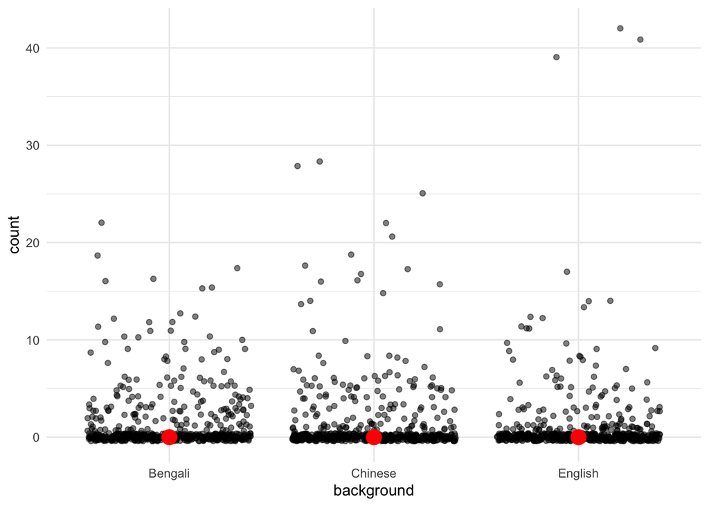

```r
gestures %>%
  ggplot(aes(background, count)) +
  geom_jitter(alpha = 0.5) +
  stat_summary(fun = median, colour = "red", size = 1)
```

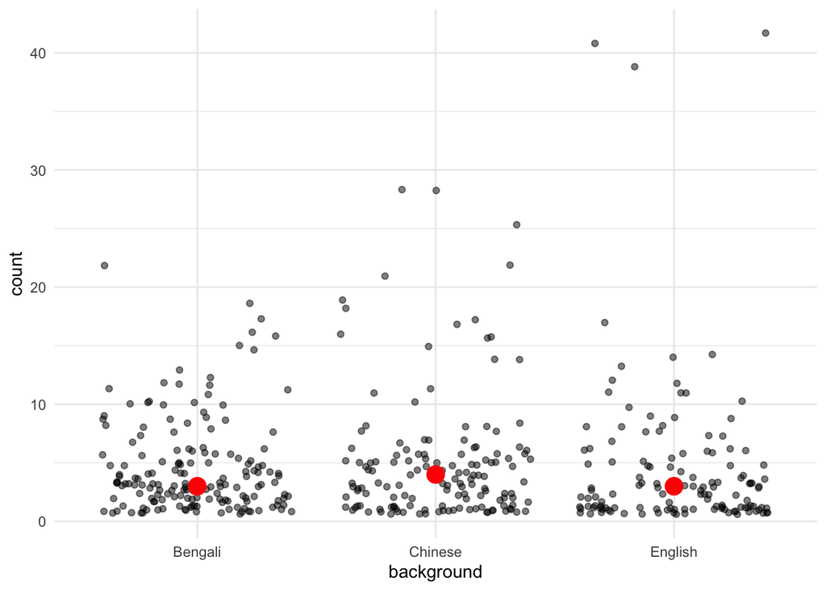

```r
gestures %>%
  filter(count > 0) %>%
  ggplot(aes(background, count)) +
  geom_jitter(alpha = 0.5) +
  stat_summary(fun = median, colour = "red", size = 1)
```

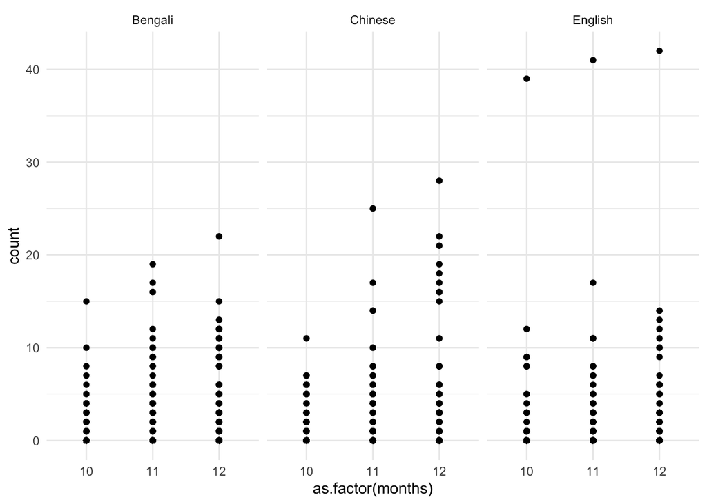

```r
gestures %>%
  ggplot(aes(as.factor(months), count)) +
  geom_point() +
  facet_grid(~ background)
```

Let’s track each dyad and each task across months 10-11-12, separately for each gesture type.

We can use a “connected points” plot.

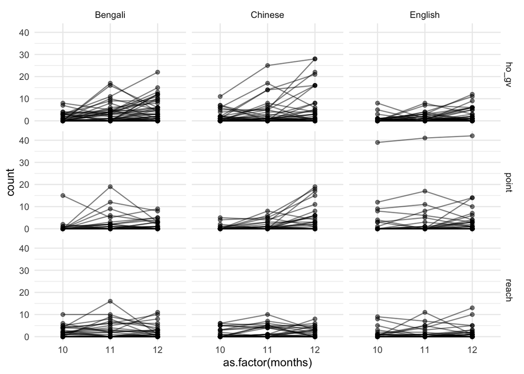

```r
gestures %>%
  mutate(id = paste(dyad, task, sep = "_")) %>%
  ggplot(aes(as.factor(months), count, group = id)) +
  geom_line(alpha = 0.5) +
  geom_point(alpha = 0.5) +
  facet_grid(gesture ~ background)
```

What if we want to do the same thing but aggregate different tasks together?

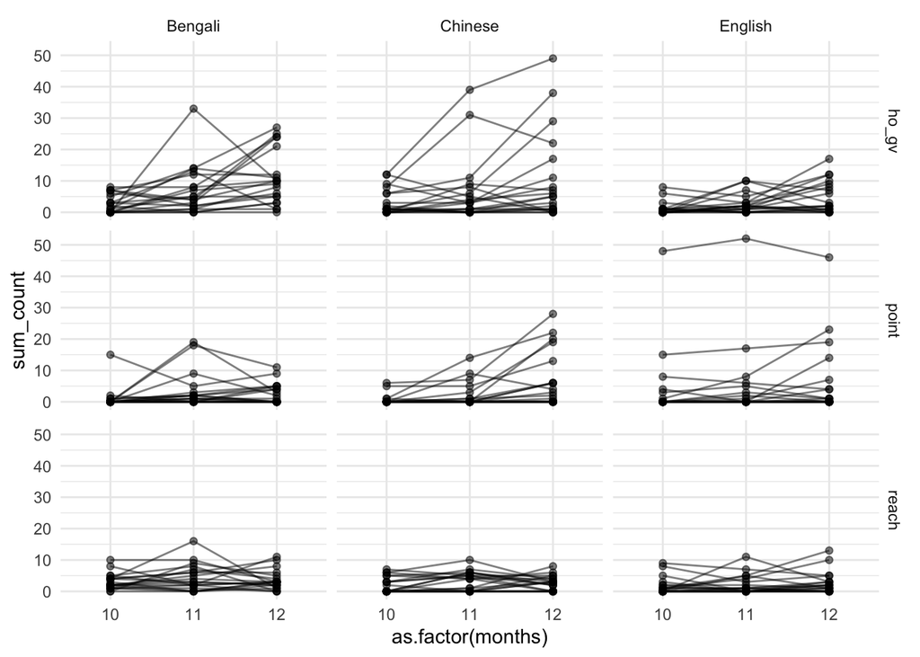

```r
gestures %>%
  group_by(background,dyad, months, gesture) %>%
  summarise(
    sum_count = sum(count, na.rm = TRUE)
  ) %>%
  ggplot(aes(as.factor(months), sum_count, group = dyad)) +
  geom_line(alpha = 0.5) +
  geom_point(alpha = 0.5) +
  facet_grid(gesture ~ background)
```

What can you see from this plot?